# BENN_Project2.Rmd

Maleah Benn

2/22/2022

The Study 1 GWAS included 4 principal components (PCs) as covariates as well as sex and age. This selection was based on the scree plot in the R script. The amount of variance explained is almost zero once PC5 is reached, so only the first 4 were included in the analyses as the majority of variance can be explained by these PCs. The Study 2 GWAS included age, sex, and PCs 1-4 as covariates.

The sample sizes for GWAS1 and GWAS2 are summarized below.

```
##    Min. 1st Qu.  Median    Mean 3rd Qu.    Max.
##    1214    1277    1277    1277    1277    1277
```

```
##    Min. 1st Qu.  Median    Mean 3rd Qu.    Max.
##    1165    1226    1226    1226    1226    1226
```

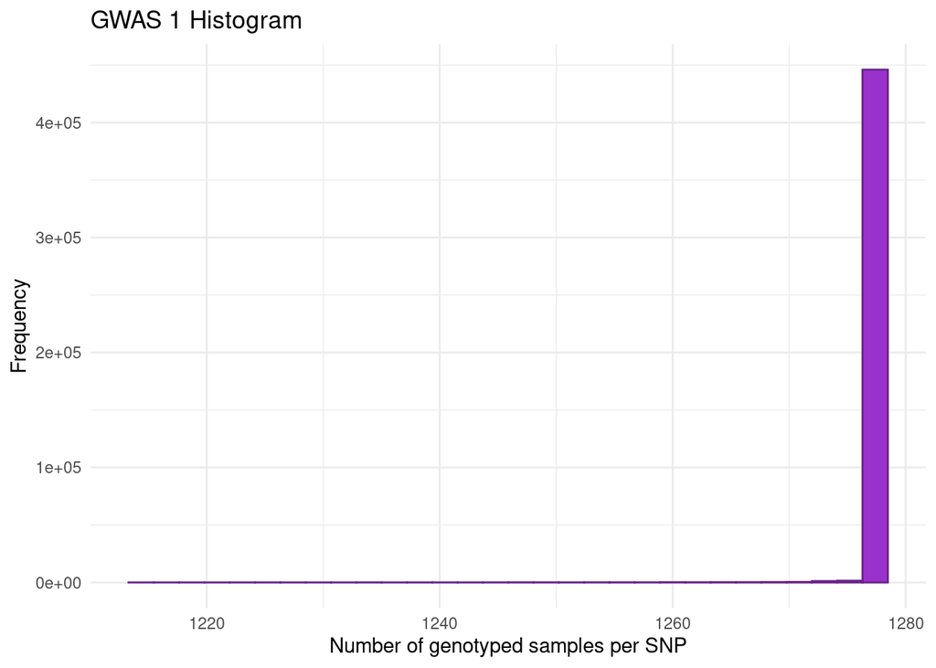

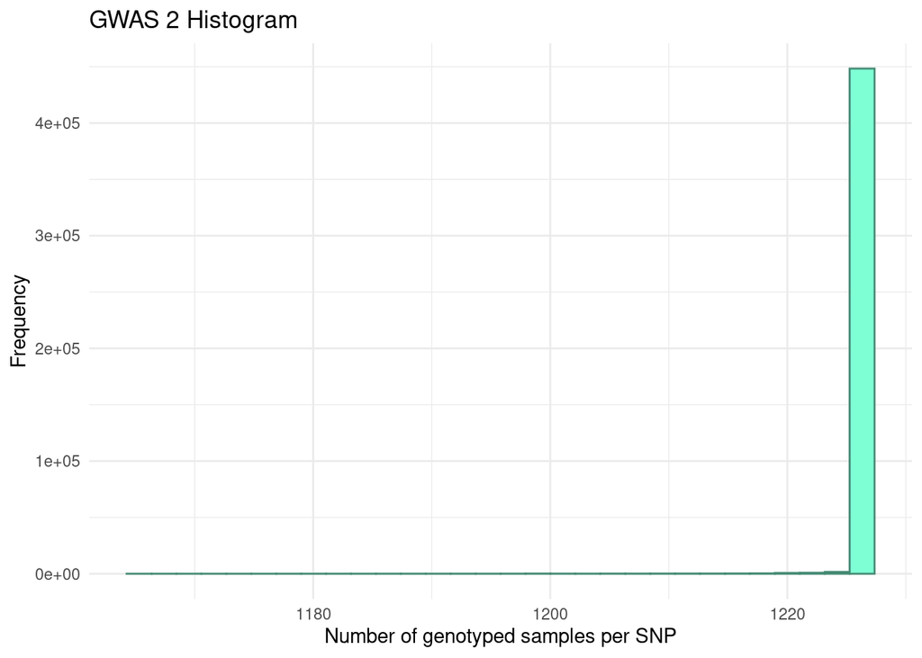

```r
# study 1 variants
nrow(study_1_GWAS)
```

```
## [1] 451832
```

```r
# study 2 variants
nrow(study_2_GWAS)
```

```
## [1] 454154
```

After EasyQC filtering, GWAS 1 included 451,832 variants while GWAS 2 included 454,154 variants.

According to the EasyQC report, GWAS1 dropped 17 variants and GWAS2 dropped 14. All dropped variants in both studies were excluded because they were duplicates. There were 68 variants flagged as outliers during the allele frequency check in GWAS1. There were 71 variants flagged as outliers during the allele frequency check in GWAS2. There were 29 variants in each study that were flagged for an invalid reference allele.

The Manhattan plots, QQ plots, and lambdas are shown below for GWAS1 and GWAS2.

```
## [1] 0.9695496
```

```
## [1] 0.9930195
```

```
## Classes 'data.table' and 'data.frame':   451832 obs. of  13 variables:
##  $ cptid        : chr  "10:100004116" "10:100007694" "10:100011970" "10:100021733" ...
##  $ SNP          : chr  "rs74874612" "rs41307056" "rs3750598" "rs73327617" ...
##  $ STRAND       : chr  "+" "+" "+" "+" ...
##  $ EFFECT_ALLELE: chr  "A" "A" "A" "A" ...
##  $ OTHER_ALLELE : chr  "G" "G" "G" "G" ...
##  $ EAF          : num  0.018 0.0129 0.3269 0.0243 0.011 ...
##  $ BETA         : num  0.545 -0.501 0.156 0.136 -0.367 ...
##  $ SE           : num  0.774 0.886 0.215 0.651 0.9 ...
##  $ PVAL         : num  0.481 0.572 0.468 0.835 0.683 ...
##  $ N            : int  1277 1277 1277 1277 1277 1277 1277 1277 1277 1277 ...
##  $ MAC          : num  46 33 835 62 28 ...
##  $ chr          : num  10 10 10 10 10 10 10 10 10 10 ...
##  $ bp           : num  1e+08 1e+08 1e+08 1e+08 1e+07 ...
##  - attr(*, ".internal.selfref")=<externalptr>
```

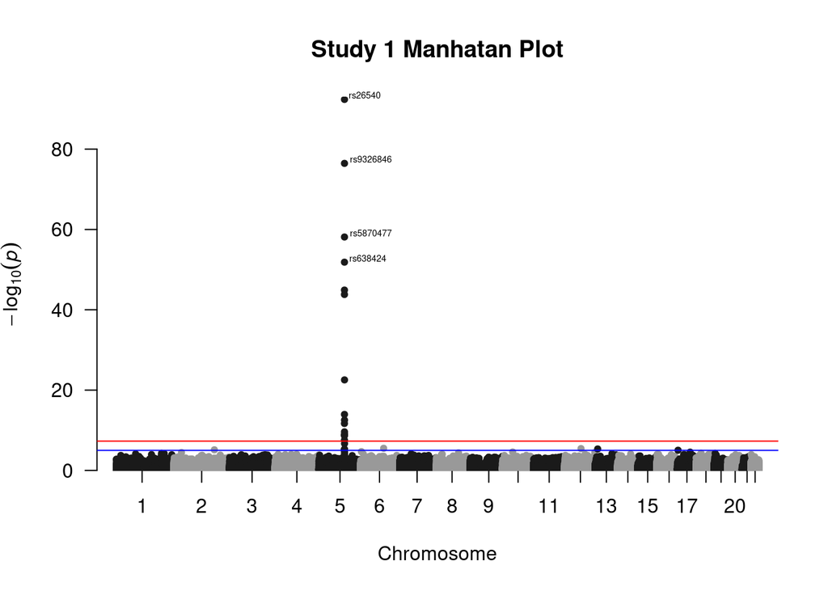

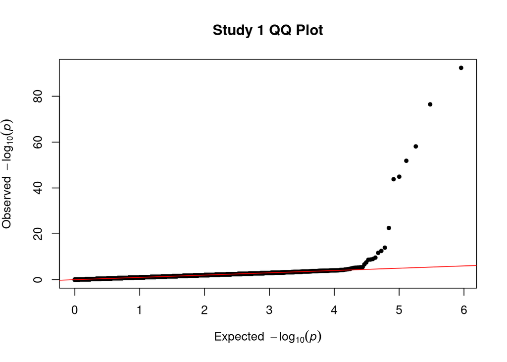

```
## Classes 'data.table' and 'data.frame':   454154 obs. of  13 variables:
##  $ cptid        : chr  "10:100004116" "10:100007694" "10:100011970" "10:100021733" ...
##  $ SNP          : chr  "rs74874612" "rs41307056" "rs3750598" "rs73327617" ...
##  $ STRAND       : chr  "+" "+" "+" "+" ...
##  $ EFFECT_ALLELE: chr  "A" "A" "A" "A" ...
##  $ OTHER_ALLELE : chr  "G" "G" "G" "G" ...
##  $ EAF          : num  0.0298 0.0114 0.3157 0.0228 0.0102 ...
##  $ BETA         : num  -0.1767 0.3763 0.0179 0.233 -0.458 ...
##  $ SE           : num  0.593 0.938 0.215 0.67 0.964 ...
##  $ PVAL         : num  0.766 0.688 0.934 0.728 0.635 ...
##  $ N            : int  1226 1226 1226 1226 1226 1226 1226 1226 1226 1226 ...
##  $ MAC          : num  73 28 774 56 25 ...
##  $ chr          : num  10 10 10 10 10 10 10 10 10 10 ...
##  $ bp           : num  1e+08 1e+08 1e+08 1e+08 1e+07 ...
##  - attr(*, ".internal.selfref")=<externalptr>
```

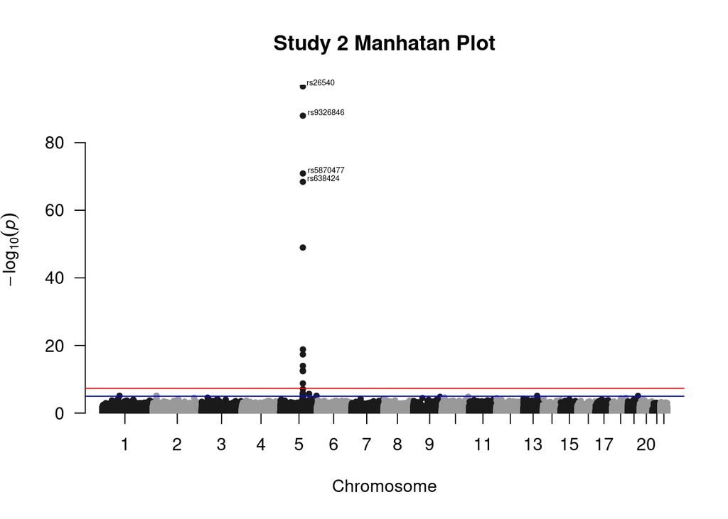

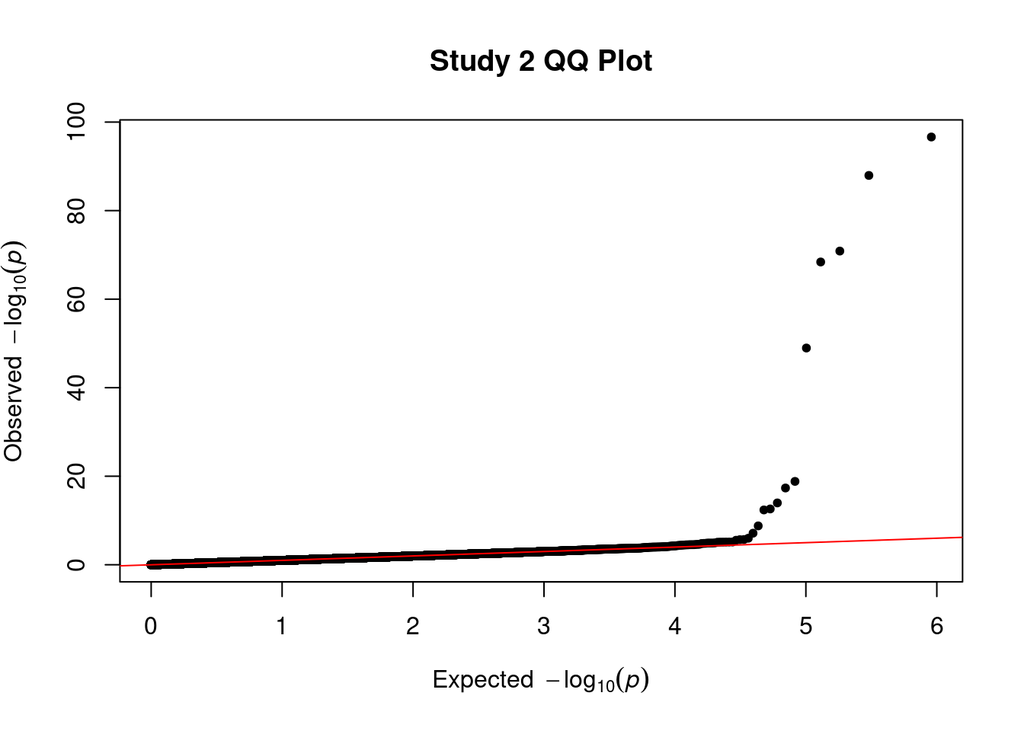

Given that our phenotype of interest is quantitative (not case/control), a conservative minor allele count threshold of 6 has been applied to both studies where any SNPs with an MAC of 6 or more have been retained. Additionally, any SNPs that had missing genotype calls for 30 or more samples were excluded (N >= 1,247 and 1,196 for study 1 and 2, respectively). After filtering by these thresholds, GWAS1 has retained 451,085 SNPs (747 excluded) and GWAS2 has 453,453 SNPs (701 excluded).

The distribution of the minor allele counts and sample sizes for the two studies are shown below.

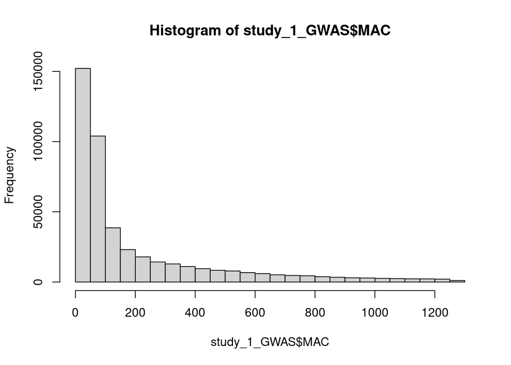

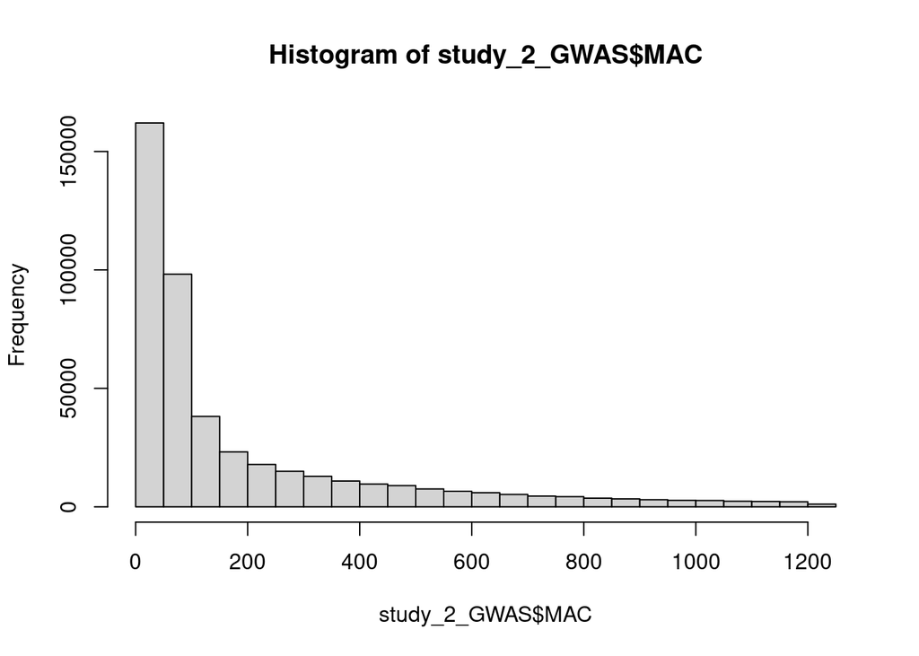

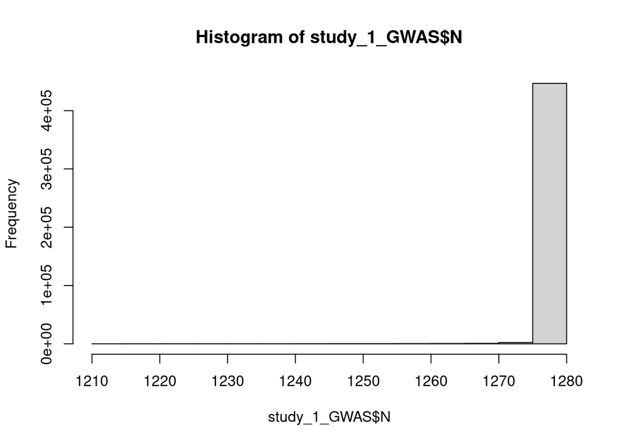

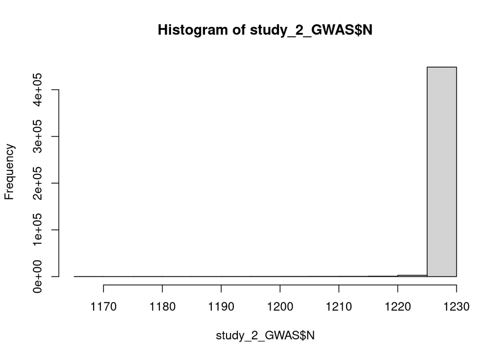

```
##           cptid         SNP STRAND EFFECT_ALLELE OTHER_ALLELE     EAF    BETA
## 1: 10:100004116  rs74874612      +             A            G 0.01801  0.5449
## 2: 10:100007694  rs41307056      +             A            G 0.01292 -0.5007
## 3: 10:100011970   rs3750598      +             A            G 0.32690  0.1562
## 4: 10:100021733  rs73327617      +             A            G 0.02428  0.1357
## 5:  10:10002281 rs550789161      +             A            G 0.01096 -0.3671
## 6: 10:100026709   rs7089690      +             A            G 0.13590 -0.3162
##        SE   PVAL    N    MAC chr        bp
## 1: 0.7736 0.4812 1277  46.00  10 100004116
## 2: 0.8862 0.5721 1277  33.00  10 100007694
## 3: 0.2152 0.4680 1277 834.90  10 100011970
## 4: 0.6514 0.8350 1277  62.01  10 100021733
## 5: 0.9000 0.6833 1277  27.99  10  10002281
## 6: 0.2886 0.2733 1277 347.10  10 100026709
```

```
## [1] 451085
```

```
## [1] 747
```

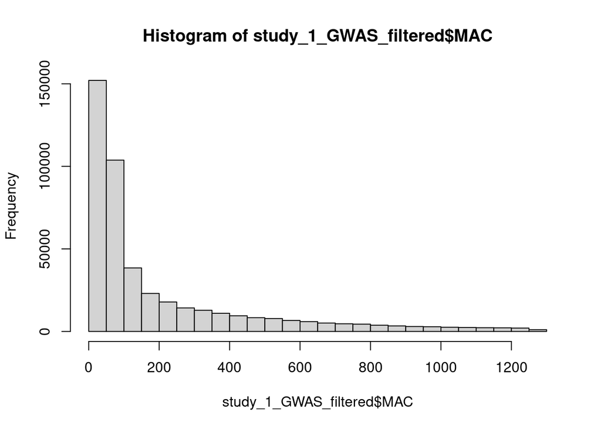

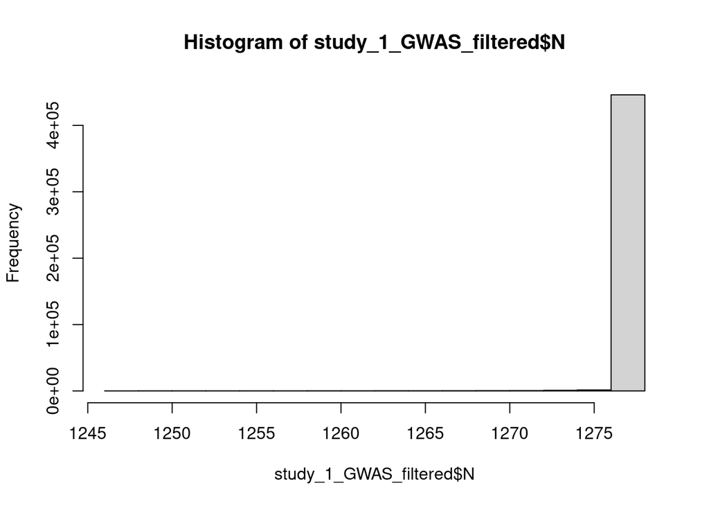

```
##           cptid         SNP STRAND EFFECT_ALLELE OTHER_ALLELE     EAF     BETA
## 1: 10:100004116  rs74874612      +             A            G 0.02977 -0.17670
## 2: 10:100007694  rs41307056      +             A            G 0.01142  0.37630
## 3: 10:100011970   rs3750598      +             A            G 0.31570  0.01786
## 4: 10:100021733  rs73327617      +             A            G 0.02284  0.23300
## 5:  10:10002281 rs550789161      +             A            G 0.01020 -0.45800
## 6: 10:100026709   rs7089690      +             A            G 0.13050  0.37740
##        SE   PVAL    N    MAC chr        bp
## 1: 0.5926 0.7656 1226  73.00  10 100004116
## 2: 0.9375 0.6882 1226  28.00  10 100007694
## 3: 0.2155 0.9339 1226 774.10  10 100011970
## 4: 0.6703 0.7281 1226  56.00  10 100021733
## 5: 0.9636 0.6346 1226  25.01  10  10002281
## 6: 0.2914 0.1952 1226 320.00  10 100026709
```

```
## [1] 453453
```

```
## [1] 701
```

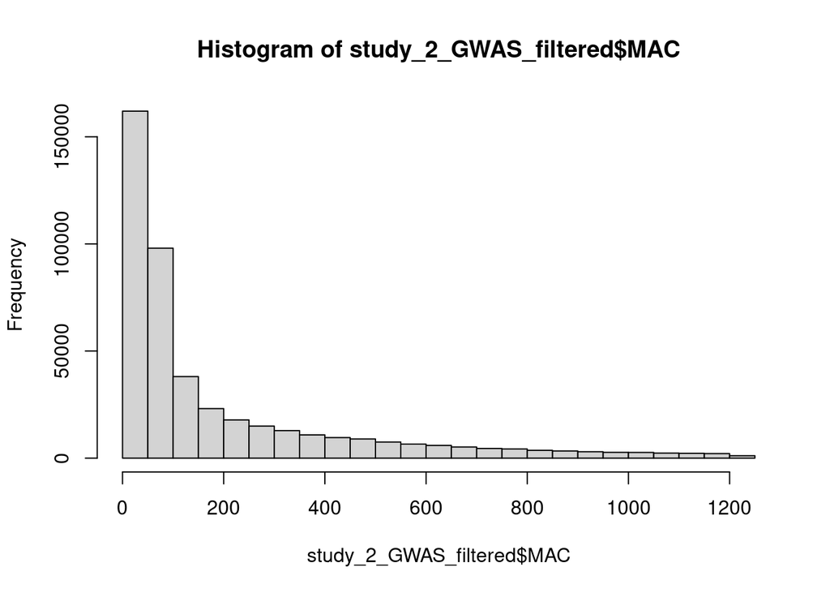

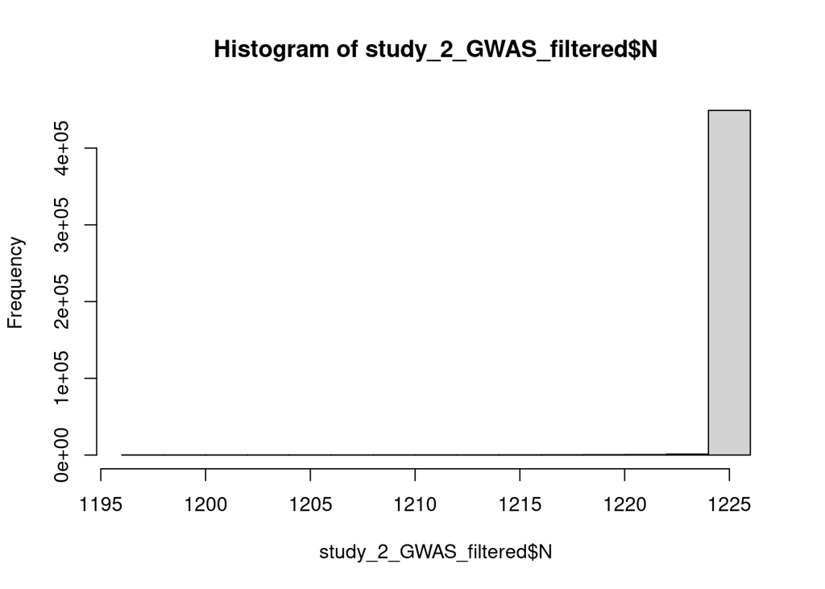

```
## [1] 0.9695496
```

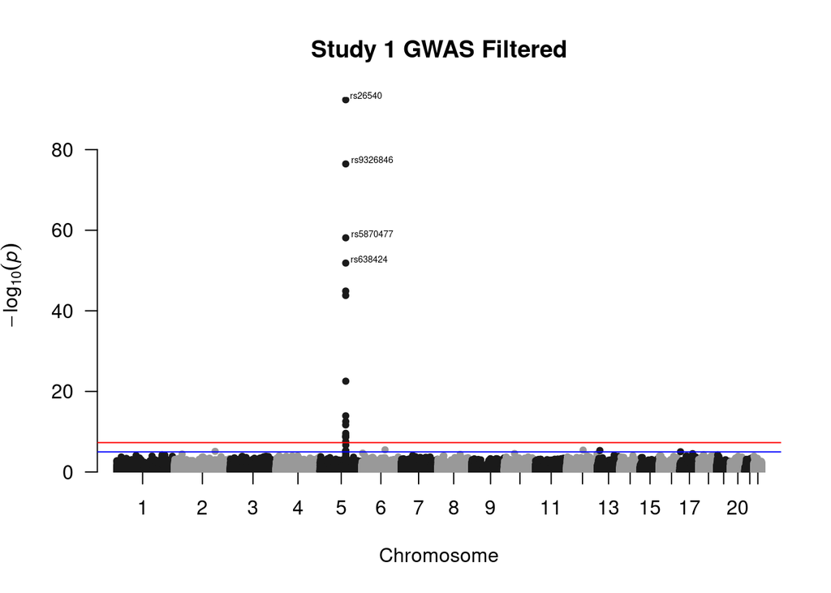

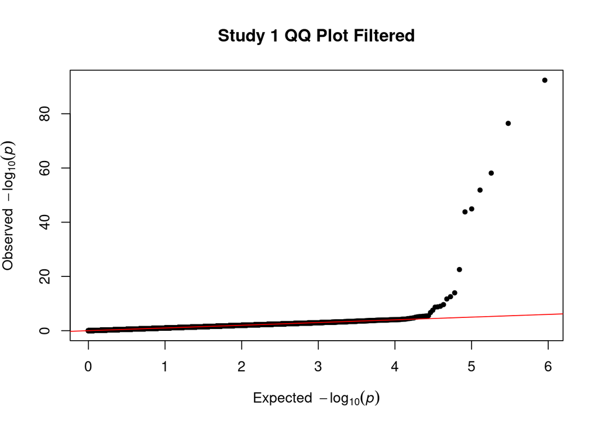

```
## [1] 0.9930195
```

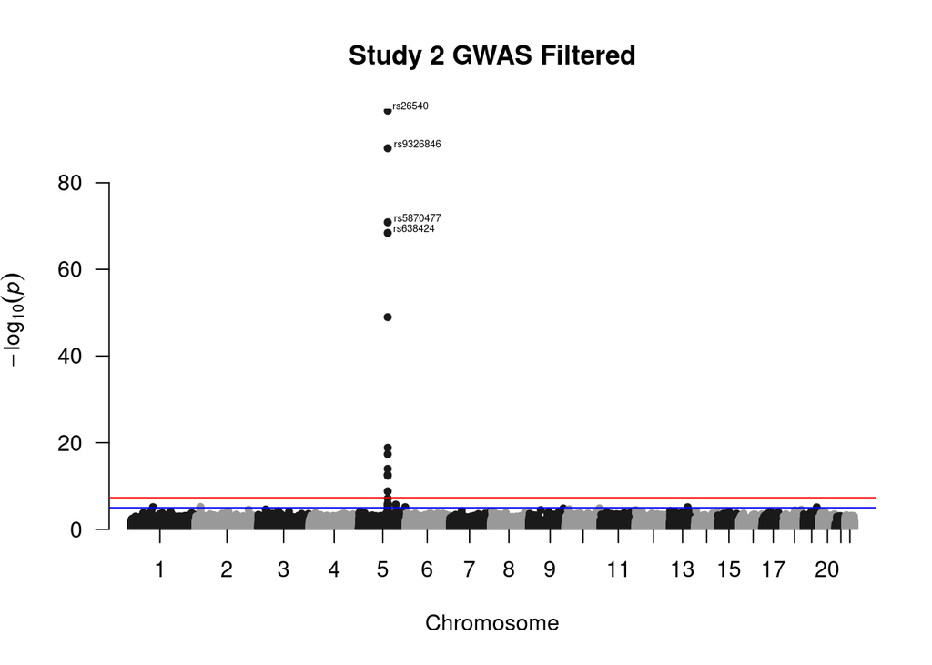

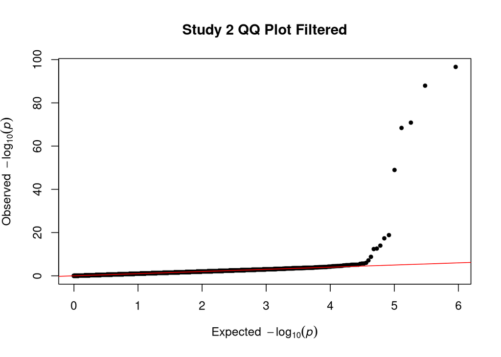

After filtering both studies by a MAC threshold of 6 and an N of 30, neither the Manhattan nor the qq plots seem to have changed much. Additionally, the lambda values for both the filtered and unfiltered studies are nearly identical. Given that, and the fact that neither lambda is greater than 1.1, there is no indication of inflation in either study.

A table summarizing the effect direction across studies in the meta analysis is shown below. The first character represents the effect direction in GWAS1 and the second character indicates effect direction in GWAS2.

Frequency of effect direction in meta analysis results

| . | Freq |
| --- | --- |
| – | 109476 |
| -? | 9960 |
| -+ | 107670 |
| -0 | 9 |
| ?- | 10875 |
| ?+ | 11014 |
| ?0 | 3 |
| +- | 107602 |
| +? | 9609 |
| ++ | 107479 |
| +0 | 10 |
| 0- | 10 |
| 0? | 1 |
| 0+ | 6 |

```
## [1] 0.5019063
```

There are 432,262 SNPs that appear in both GWAS1 and GWAS2. There are 19,570 SNPs that only appear in GWAS1 and 21,892 that are unique in GWAS2. Among these, 50.2% had the same effect direction across both studies.

Manhattan plot, QQ plot, and lambda for the meta analysis are shown below.

```
##     MarkerName chr        bp
## 1:  rs74874612  10 100004116
## 2:  rs41307056  10 100007694
## 3:   rs3750598  10 100011970
## 4:  rs73327617  10 100021733
## 5: rs550789161  10  10002281
## 6:   rs7089690  10 100026709
```

```
##     MarkerName Allele1 Allele2 Weight Zscore P-value Direction chr        bp
## 1:  rs10570481       a       g   2503 -1.147  0.2513        --   6 101055059
## 2:    rs893213       a       g   1226  1.494  0.1351        ?+  NA        NA
## 3:    rs784671       a       g   2503  0.214  0.8307        +-   9 109915141
## 4:  rs12634050       a       g   1226 -0.692  0.4892        ?-  NA        NA
## 5:  rs79668407       a       g   2503 -0.710  0.4780        --   1 117547383
## 6: rs115970486       a       g   2503 -0.444  0.6570        -+  15  94921813
```

```
## [1] 473724
```

```
##    MarkerName Allele1 Allele2 Weight Zscore P-value Direction chr       bp
## 1: rs34954147       a       g   2503  0.383  0.7019        -+  10 10038695
```

```
##          cptid        SNP STRAND EFFECT_ALLELE OTHER_ALLELE     EAF     BETA
## 1: 10:10038695 rs34954147      +             A            G 0.02388 -0.03937
##        SE   PVAL    N   MAC chr       bp
## 1: 0.6653 0.9528 1277 60.99  10 10038695
```

```
##     MarkerName Allele1 Allele2 Weight Zscore   pval Direction chr        bp
## 1:  rs10570481       a       g   2503 -1.147 0.2513        --   6 101055059
## 2:    rs893213       a       g   1226  1.494 0.1351        ?+  NA        NA
## 3:    rs784671       a       g   2503  0.214 0.8307        +-   9 109915141
## 4:  rs12634050       a       g   1226 -0.692 0.4892        ?-  NA        NA
## 5:  rs79668407       a       g   2503 -0.710 0.4780        --   1 117547383
## 6: rs115970486       a       g   2503 -0.444 0.6570        -+  15  94921813
```

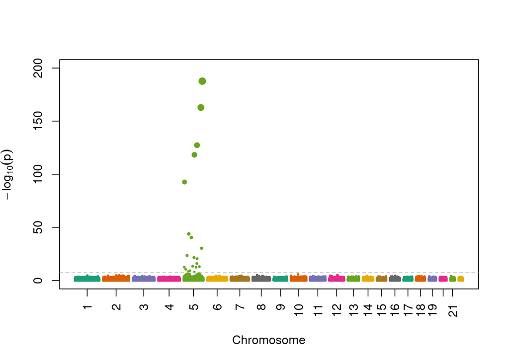

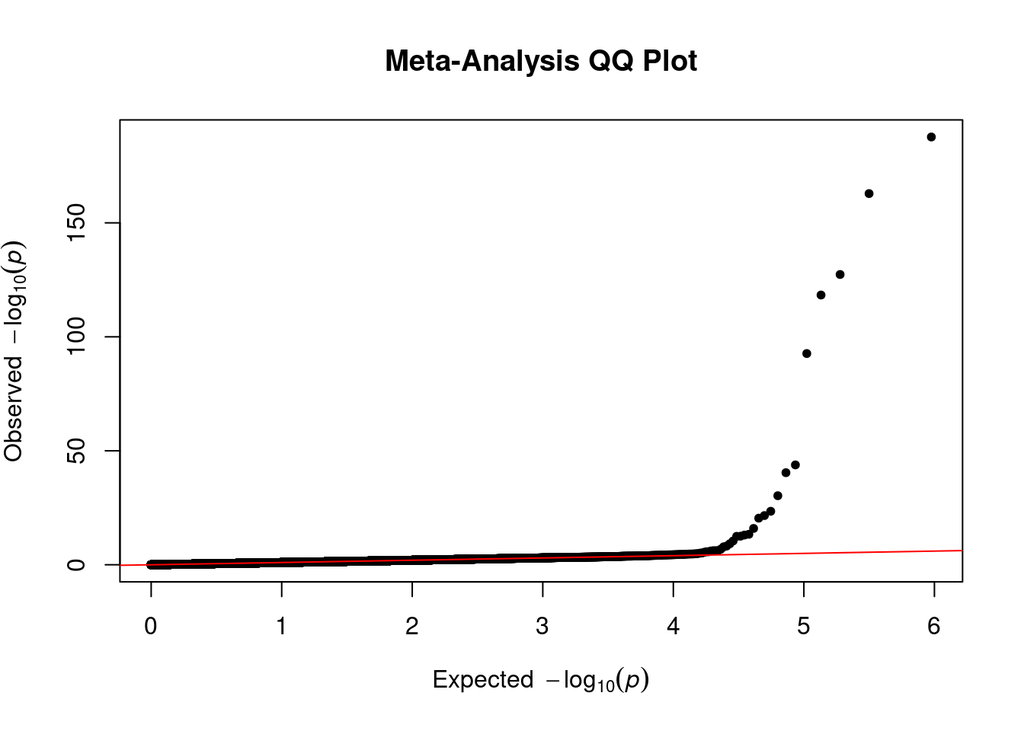

```
## [1] 0.9888482
```

```r
# thresholds
summary(meta_analysis$Weight)
```

```
##    Min. 1st Qu.  Median    Mean 3rd Qu.    Max.
##    1165    2503    2503    2393    2503    2503
```

```r
# merge in mac
meta_temp_2 <- study_1_GWAS[,c(2,11)] %>% rename(MarkerName = SNP)
meta_analysis <- left_join(meta_analysis,meta_temp_2, by.x=MarkerName, by.y=MarkerName)
head(meta_analysis)
```

```
##     MarkerName Allele1 Allele2 Weight Zscore   pval Direction chr        bp
## 1:  rs79668407       a       g   2503 -0.710 0.4780        --   1 117547383
## 2: rs140384385       a       g   2503 -0.731 0.4646        --   1 158274604
## 3: rs143278271       a       g   1277  1.252 0.2104        +?   1 218930253
## 4:   rs7518432       a       g   2503 -0.358 0.7200        --   1  39363522
## 5:   rs9333480       a       g   2503 -0.820 0.4124        --   1 165621419
## 6: rs139581921       a       g   2503 -0.377 0.7058        +-   1   1609070
##       MAC
## 1: 119.00
## 2:  26.00
## 3:  28.99
## 4: 786.10
## 5:  69.01
## 6:  33.99
```

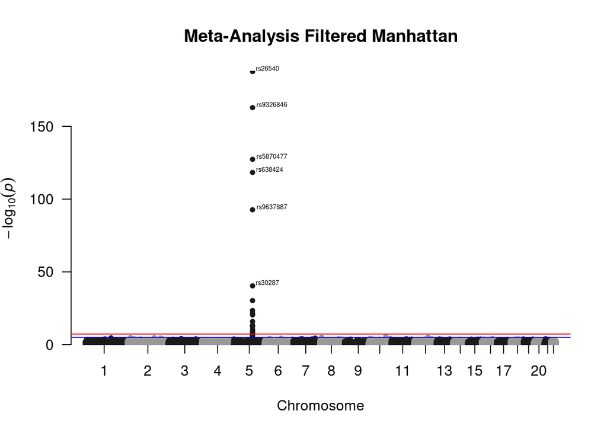

```r
meta_filtered <- meta_analysis %>% filter(MAC >= 6 & Weight >= 2473)

# new plots
meta_man_filt <- manhattan(meta_filtered, chr="chr", snp="MarkerName", p="pval", bp = "bp", main = "Meta-Analysis Filtered Manhattan", annotatePval = 1e-40, annotateTop = FALSE)
```

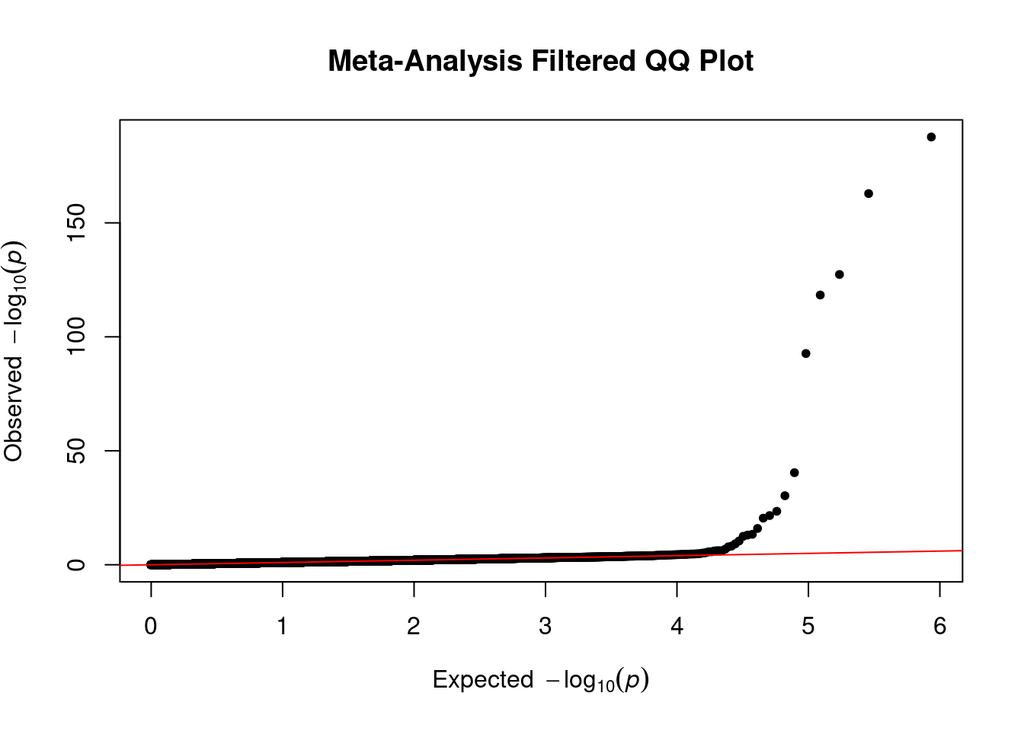

```r
# meta qq
meta_qq_filt <- qq(meta_filtered$pval, main = "Meta-Analysis Filtered QQ Plot")
```

```r
# meta lambda
## create p value vector
meta_p_filt <- as.vector(meta_filtered$pval)
## calculate lambda
meta_lam_filt <- median(qchisq(1-meta_p_filt,1))/qchisq(0.5,1)
```

With the filters set above, the strongest associated SNP was determined.

```
##    MarkerName Allele1 Allele2 Weight  Zscore       pval Direction chr        bp
## 1:    rs26540       a       g   2503  29.275 2.180e-188        ++   5 111349320
## 2:  rs9326846       a       g   2503  27.255 1.460e-163        ++   5 111301546
## 3:  rs5870477       a       g   2503 -24.075 4.530e-128        --   5 111285059
## 4:   rs638424       a       g   2503  23.199 4.670e-119        ++   5 111248399
## 5:  rs9637887       a       g   2503  20.500  2.150e-93        ++   5 111173095
## 6:    rs30287       a       g   2503 -13.430  4.045e-41        --   5 111460327
##     MAC
## 1: 1193
## 2: 1166
## 3: 1251
## 4: 1207
## 5: 1142
## 6: 1099
```

```
## [1] 157656
```

```
##    MarkerName Allele1 Allele2 Weight Zscore   pval Direction chr       bp MAC
## 1:  rs9625189       a       g   2503  -0.64 0.5224        +-  22 27641756 392
```

```
## [1] 324020
```

```
##          cptid     SNP STRAND EFFECT_ALLELE OTHER_ALLELE    EAF  BETA     SE
## 1: 5:111349320 rs26540      +             A            G 0.4671 4.111 0.2008
##         PVAL    N  MAC chr        bp
## 1: 4.208e-93 1277 1193   5 111349320
```

```
## [1] 326047
```

```
##          cptid     SNP STRAND EFFECT_ALLELE OTHER_ALLELE    EAF  BETA     SE
## 1: 5:111349320 rs26540      +             A            G 0.4653 4.253 0.2031
##         PVAL    N  MAC chr        bp
## 1: 2.308e-97 1226 1141   5 111349320
```

The strongest association in the meta analysis is SNP rs26540 with a p value of 2.18e-188. This SNP is located on chromosome 5 at basepair position 111,349,320. In GWAS study 1, this SNP had a p value of 4.208e-93 with an effect size of 4.11. In GWAS study 2, this SNP had a p value of 2.308e-97 with an effect size of 4.253. Both individual studies and the meta analysis are consistent in positive effect direction for this SNP.

A regional Manhattan plot 1Mb surrounding the SNP of intestest is shown below.

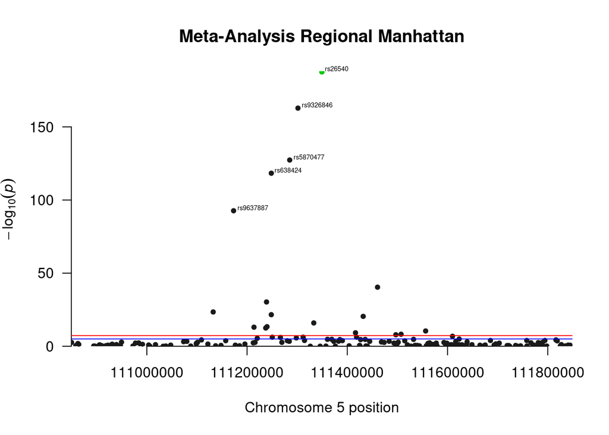

```
## $xpd
## [1] TRUE
```

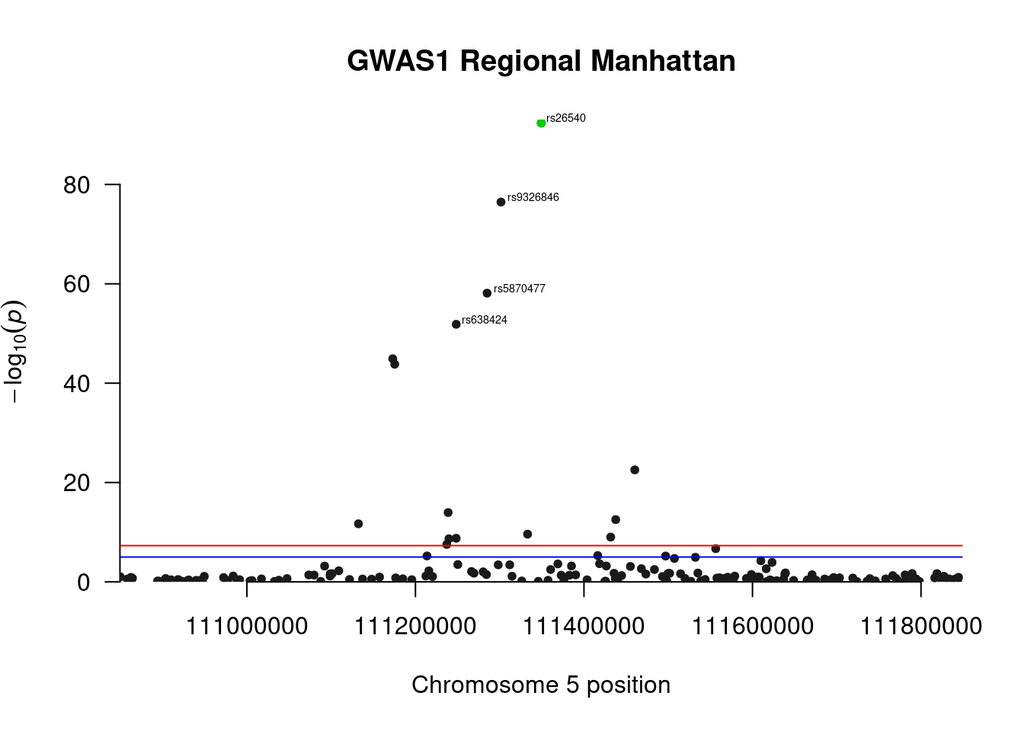

```
## $xpd
## [1] TRUE
```

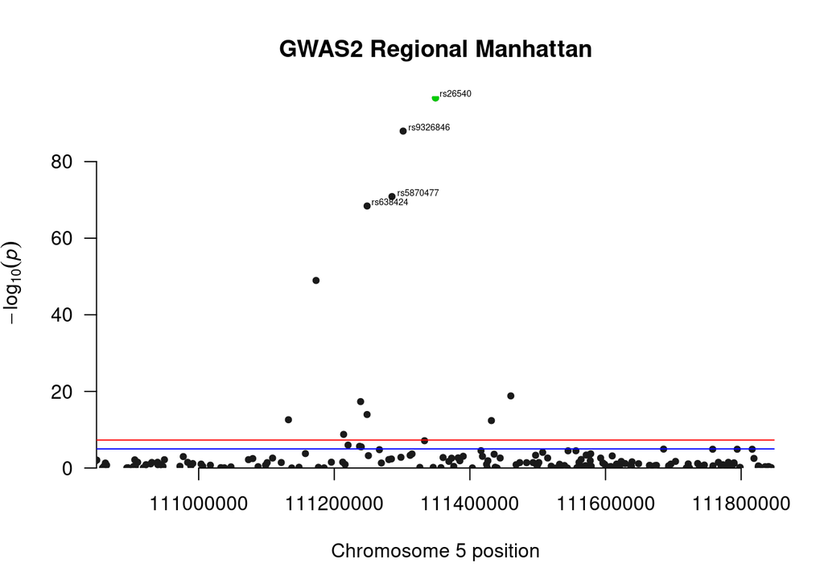

```
## $xpd
## [1] TRUE
```

The effect size and standard errors were used to create 95% confidence intervals for rs26540 in both GWAS1 and GWAS2. That information was then plotted in the forest plot shown below.

```
##
## Fixed-Effects Model (k = 2)
##
##   logLik  deviance       AIC       BIC      AICc
##   1.2380    0.2472   -0.4761   -1.7829    3.5239
##
## I^2 (total heterogeneity / total variability):   0.00%
## H^2 (total variability / sampling variability):  0.25
##
## Test for Heterogeneity:
## Q(df = 1) = 0.2472, p-val = 0.6191
##
## Model Results:
##
## estimate      se     zval    pval   ci.lb   ci.ub
##   4.1812  0.1428  29.2814  <.0001  3.9013  4.4611  ***
##
## ---
## Signif. codes:  0 '***' 0.001 '**' 0.01 '*' 0.05 '.' 0.1 ' ' 1
```

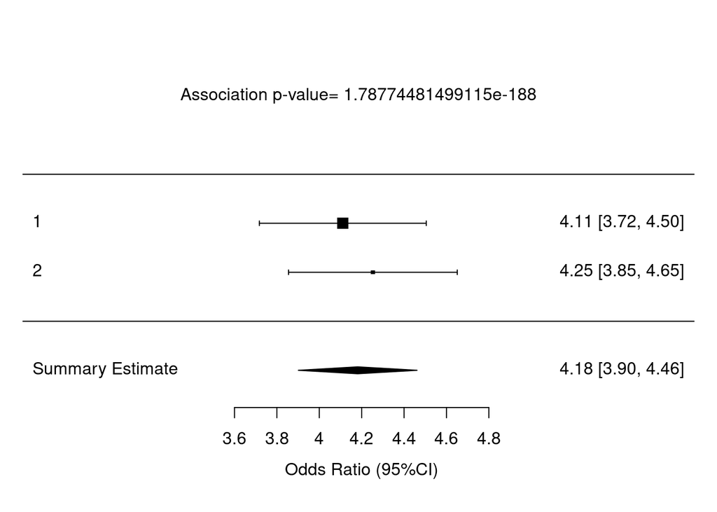